# Piping and ggplot introduction

08 March, 2020

## Before we start

**Required packages, data and scripts:**

- The **readr** and **dplyr** packages
- The data file: `CENTRAL_AMERICA_STORMS.CSV` (on Blackboard)
- A template R script: `block-3-template.R` (on Blackboard)

**Make sure you carry out these steps:**

- Set your working directory.
- Run the code to load the **dplyr** and **readr** packages:

```r
library(readr)
library(dplyr)
```

- Run the code to read the Central American storms data into R:

```r
storms <- read_csv("CENTRAL_AMERICA_STORMS.CSV")
```

**Check for errors at every step!**

## Using `%>%`

### piping or chaining

## Motivating example

We often need to perform a sequence of calculations. We do this by applying a series of function in sequence. Here are two ways to do this:

**Method 1: Store intermediate results…**

```r
x <- 10
x <- sqrt(x)
x <- exp(x)
round(x, 2)
```

```
## [1] 23.62
```

**Method 2: Use function nesting…**

```r
round(exp(sqrt(10)), 2)
```

```
## [1] 23.62
```

These do the same thing. Method 1 is easy to read, but is very verbose. Method 2 is concise, but not at all easy to read.

## A third way, using `%>%`…

The **dplyr** package includes a special operator called “the pipe”. The pipe operator looks like this: `%>%`.

This allows us to avoid storing intermediate results (method 1), while reading a sequence of function calls from left to right. For example:

```r
10 %>% sqrt(.) %>% exp(.) %>% round(., 2)
```

```
## [1] 23.62
```

Or equivalently, and even simpler…

```r
10 %>% sqrt() %>% exp() %>% round(2)
```

```
## [1] 23.62
```

## Why is this handy?

We can use `%>%` with any function we like. Look at these examples of a `group_by` and `summarise` that use the “traditional” methods of dealing with a sequence of calculations:

```r
# method 1 -- store intermediate results
iris_grouped <- group_by(iris, Species)
summarise(iris_grouped, meanSL = mean(Sepal.Length))
# method 2 -- one step with nested functions
summarise(group_by(iris, Species), meanSL = mean(Sepal.Length))
```

The “piped” equivalent is more natural to read…

```r
iris %>%
  group_by(Species) %>%
  summarise(meanSL = mean(Sepal.Length))
```

## Exercise

**Using `group_by` to calculate group specific summaries**

Last week we used `group_by` and `summarise` with the `storms` data set to calculate the mean wind speed associated with each type of storm. Repeat this exercise but now use the pipe. Print the results directly to the Console.

```r
storms %>%
  group_by(type) %>%
  summarise(mean_speed = mean(wind))
```

```
## # A tibble: 4 x 2
##   type                mean_speed
##   <chr>                    <dbl>
## 1 Extratropical             40.1
## 2 Hurricane                 84.7
## 3 Tropical Depression       27.4
## 4 Tropical Storm            47.3
```

## Exercise

**Using `group_by` to calculate group specific summaries**

Last week we used `group_by` and `summarise` with the `storms` data set to calculate the mean wind speed associated with each type of storm. Repeat this exercise but now use the pipe. Store the results and then use `glimpse` to summarise them.

```r
storms_summary <-
  storms %>%
  group_by(type) %>%
  summarise(mean_speed = mean(wind))

glimpse(storms_summary)
```

```
## Observations: 4
## Variables: 2
## $ type       <chr> "Extratropical", "Hurricane", "Tropical Depression", "Trop…
## $ mean_speed <dbl> 40.06068, 84.65960, 27.35867, 47.32181
```

## Overview of **ggplot2**

### The grammar of graphics

## Why use **ggplot2**?

Roughly speaking, there are three commonly used plotting frameworks in R.

- base graphics
- **lattice** package
- **ggplot2** package

**Advantages** of using **ggplot2**

- Consistent and intuitive framework for plotting
- Flexible enough to make every plot you will need
- Works well with **dplyr**

**Disadvantages** of using **ggplot2**

- You have to learn “the grammar” to use it well
- Vast package, can be intimidating
- More than one way to do things

## Key concepts

You need to wrap your head around a few ideas to start using **ggplot2** effectively:

- **layers**: We build ggplot2 objects by adding one or more layers together in a stepwise way. We only plot the object when we are ready. Each layer is made up of things like data, aesthetics, geometric objects, etc.
- **aesthetics**: The word aesthetics refers to **the information** in a plot. For example, which variables are associated with the x and y axes? We specify this using the `aes` function.
- **geometric objects**: Geometric objects (“geoms”) determine how the information is displayed. For example, will it be a scatter plot or a bar plot? We can specify geoms by adding a layer via functions beginning with `geom_`.

We build up a plot by combining different functions using the `+` operator. This has nothing to do with numeric addition!

## Illustrative example

Set up the basic object–define a default data frame (`my_df`) and aesthetic mappings (`aes(...)`):

```r
ggplot_object <- ggplot(<data>,
                        aes(<aesthetic-1> = <var-1>, <aesthetic-2> = <var-2>))
```

Add a layer using a particular ‘geom’…

```r
ggplot_object <- ggplot_object + geom_<type>()
```

Show the plot–just ‘print’ the object to the console

```r
ggplot_object
```

## Real example: scatter plots

Scatter plots are used to show the relationship between 2 continuous variables. Using the `iris` dataset, let’s examine the relationship between petal length and petal width.

**STEP 1**:

We use the `aes` function inside the `ggplot` function to specify which variables we plan to display. We also have to specify where the data are:

```r
plt <- ggplot(iris, aes(x = Petal.Width, y = Petal.Length))
```

All we did here was make a `ggplot` object.

## Real example: scatter plots

We can try to print the plot to the screen:

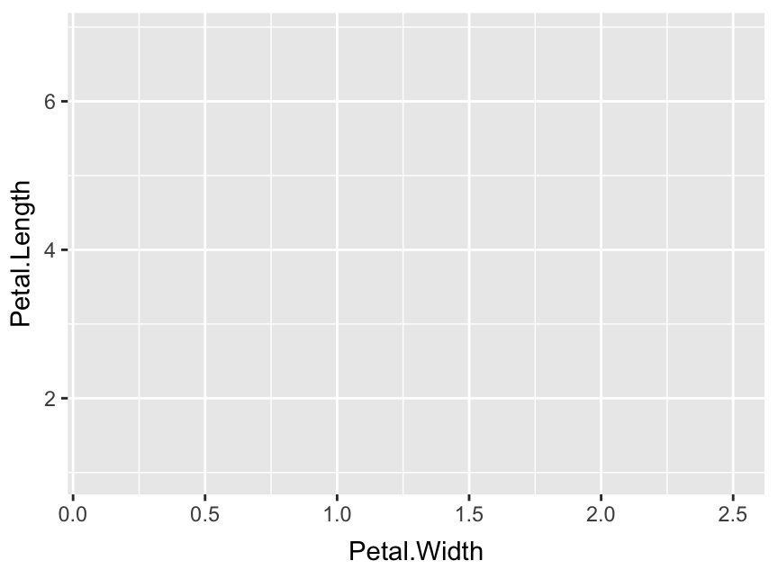

```r
plt
```

This produces an empty plot because we haven’t added a layer using a `geom_` function yet.

## Real example: scatter plots

**STEP 2**:

We want to make a scatter plot so we need to use the `geom_point` function:

```r
plt <- plt + geom_point()
```

Notice that all we do is “add” the required layer. Now we have something to plot:

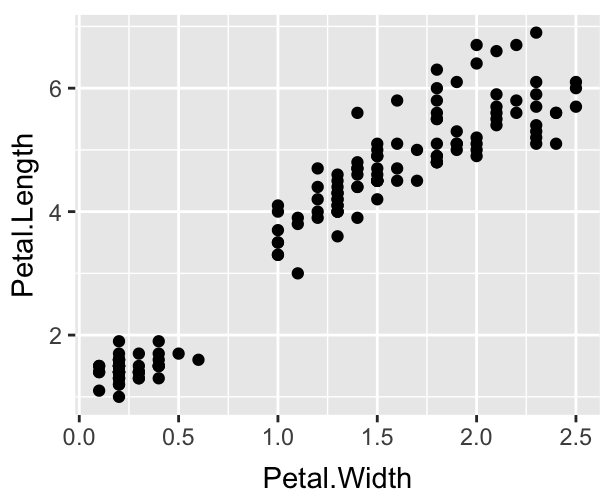

```r
plt
```

## Real example: scatter plots

**STEP 3**:

Maybe we should improve the axis labels? To do this, we need to “add” labels information using the `labs` function

```r
plt <- plt + labs(x = "Petal Width (cm)", y = "Petal Length (cm)")
plt
```

This just adds some new information about labelling to the prexisting `ggplot` object. Now it prints with improved axis labels:

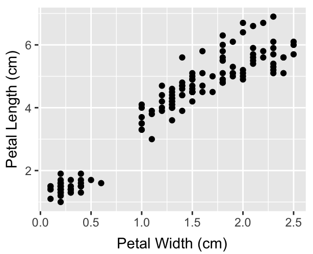

## Example: Scatter plots

**Doing it all in one go…** We don’t have to build a plot object up in separate steps and then explicitly “print” it to the Console. If we just want to make the plot in one go we can do it like this:

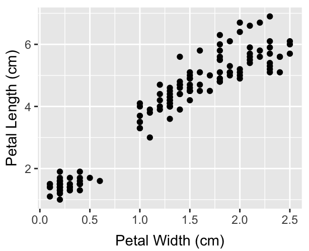

```r
ggplot(iris, aes(x = Petal.Width, y = Petal.Length)) +
  geom_point() +
  labs(x = "Petal Width (cm)", y = "Petal Length (cm)")
```

## Exercise

**Customising your plot**

Repeat the example we just stepped through, but now try to customise the point colours and their size. If that’s easy see if you can make the points semi-transparent. An example of suitable output is given below.

Hint: The `geom_point` function is responsible for altering these features. It has arguments that control properties like point colour and size.

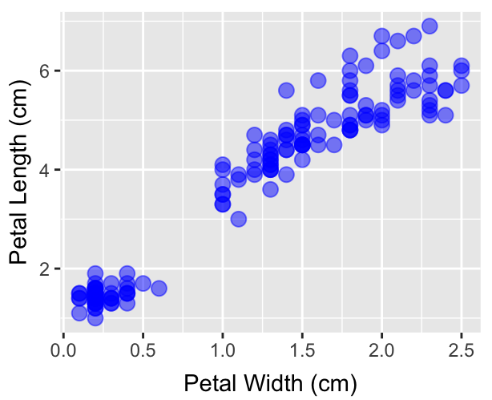

## Answer

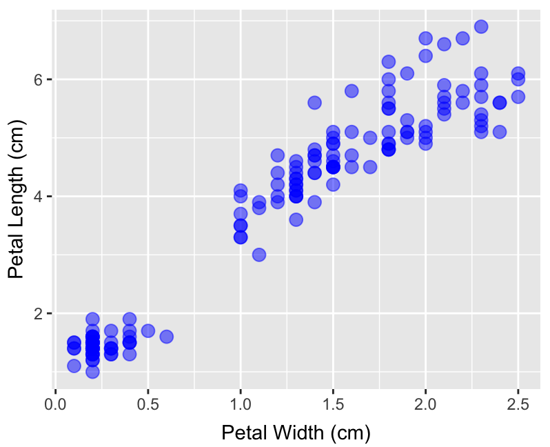

```r
ggplot(iris, aes(x = Petal.Width, y = Petal.Length)) +
  geom_point(colour = "blue", size = 3, alpha = 0.5) +
  labs(x = "Petal Width (cm)", y = "Petal Length (cm)")
```

## Adding more information

Q: The last graph was quite nice, but what information was missing?

[figure not shown]

```r
ggplot(iris, aes(x = Petal.Width, y = Petal.Length, colour = Species)) +
  geom_point(size = 3, alpha = 0.5) +
  labs(x = "Petal Width", y = "Petal Length")
```

## Exercise

**Aesthetic mappings vs. arguments to `geom_`**

Notice that we can set “colour” in two places: the aesthetic mapping (`aes`) or via an argument to a geom (`geom_`). What happens if we set the colour in both places at once?

Experiment with the iris petal length vs. petal width scatter plot example to work this out. Which one—the aesthetic mapping or geom argument—has precedence?

## Exercise

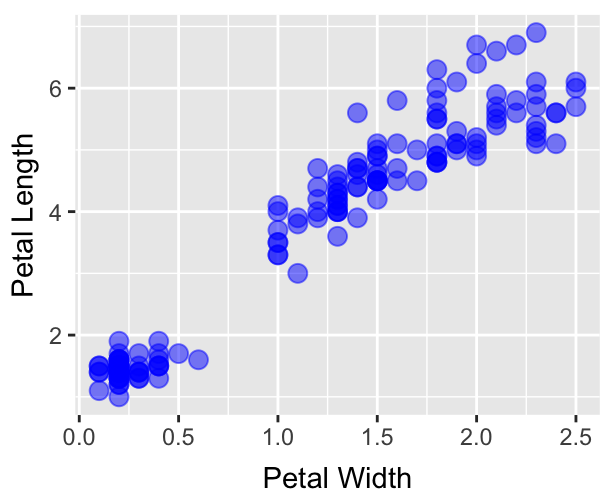

```r
ggplot(iris, aes(x = Petal.Width, y = Petal.Length, colour = Species)) +
  geom_point(colour = "blue", size = 3, alpha = 0.5) +
  labs(x = "Petal Width", y = "Petal Length")
```

## Exercise

**Using **dplyr** and **ggplot2** together (part 1)**

The first step is to work out how to use **dplyr** to calcuate the mean `wind` speed and mean `pressure` for each combination of storm `name` and `type`. Do this with the pipe (`%>%`) operator, and give the resulting data the name `storms_summary`.

```r
storms_summary <-
  storms %>%
  group_by(name, type) %>%
  summarise(wind = mean(wind), pressure = mean(pressure))
```

## Exercise

**Using **dplyr** and **ggplot2** together (part 2)**

The next step uses the `storms_summary` data to plot the mean `wind` speed and mean `pressure` for each name-type case. Remember to colour the points by `type`.

## Exercise

```r
ggplot(storms_summary,
       aes(x = pressure, y = wind, col = type)) +
  geom_point(alpha = 0.7) +
  labs(x = "Mean pressure (mbar)", y = "Mean wind speed (mph)")
```

## Exercise

**Using **dplyr** and **ggplot2** together (part 3)**

Finally, see if you can combine the solutions to part 1 and 2 into a single “piped” operation.

That is, instead of storing the intermediate data in `storms_summary`, use the pipe (`%>%`) to send the data straight to `ggplot`.

Be careful to use `%>%` and `+` in the right places.

## Exercise

```r
storms %>%
  group_by(name, type) %>%
  summarise(wind = mean(wind), pressure = mean(pressure)) %>%
  ggplot(aes(x = pressure, y = wind, col = type)) +
    geom_point(alpha = 0.7) +
    labs(x = "Mean pressure (mbar)", y = "Mean wind speed (mph)")
```

## Histograms

### Visualising a single variable

## What are histograms?

Histograms summarise the relative frequency of different values of a variable. Look at the first 56 values of `pressure` variable in `storms`:

```r
storms $ pressure[1:56]
```

```
##  [1] 1005 1004 1003 1001  997  995  987  988  988  990  990  993  993  994  995
## [16]  995  992  990  988  984  982  984  989  993  995  996  997 1000  997  990
## [31]  992  992  993 1019 1019 1018 1017 1016 1013 1011 1009 1007 1004 1001  997
## [46]  997  997  997  996  995  993  991  990  989 1012 1012
```

To get a sense of how frequent different values are we can “bin” the data. Here are the frequencies of `pressure` variable values, using 8 bins (you don’t need to remember this R code):

```r
table(cut(storms $ pressure, breaks = 8))
```

```
##
##        (905,919]        (919,934]        (934,948]        (948,962]
##                5               23               80              164
##        (962,976]        (976,990]      (990,1e+03] (1e+03,1.02e+03]
##              307              558              943              667
```

## What are histograms?

We use histograms to understand the **distribution** of a variable. They summarise the number of observations occuring in a contiguous series of bins. We can use `geom_histogram` to construct a histogram. Here is an example:

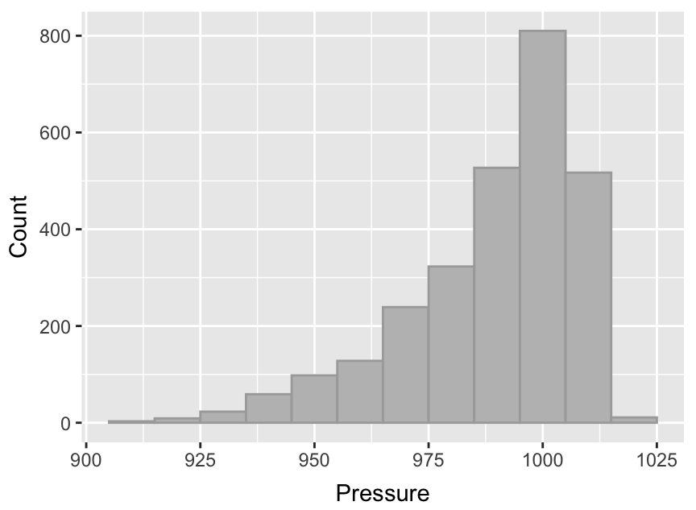

```r
ggplot(storms, aes(x = pressure)) +
  geom_histogram(colour = "darkgrey", fill = "grey", binwidth=10) +
  labs(x = "Pressure", y = "Count")
```

## Exercise

**Plotting histograms**

Working with the `iris` dataset, construct a histogram of the ratio of petal length to petal width. See if you can make you histogram look like the one below.

Hint: you can carry out the calculation with `Petal.Length` and `Petal.Width` inside `aes`.

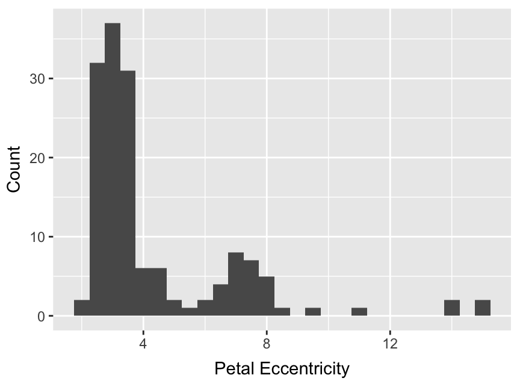

## Answer

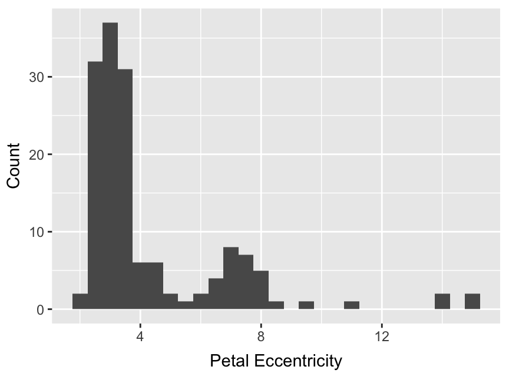

```r
ggplot(iris, aes(x = Petal.Length / Petal.Width)) +
  geom_histogram(binwidth=0.5) +
  labs(x = "Petal Eccentricity", y = "Count")
```

## Alternative to histograms

### visualising ‘small’ data

## Dot plots

We use dot plots to explore the **distribution** of variables when we have relatively few observations (e.g. < 100). Here is an example:

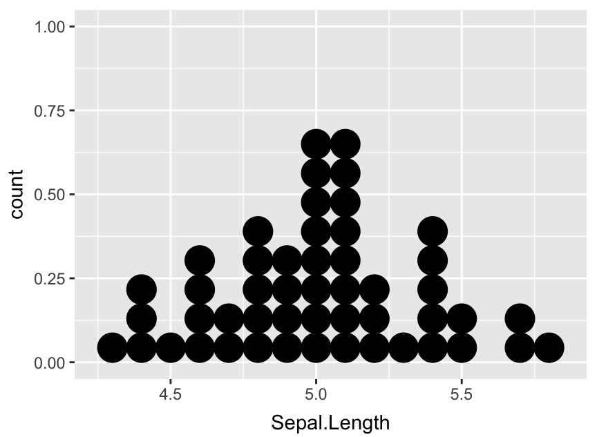

```r
setosa <- filter(iris, Species == "setosa")
ggplot(setosa, aes(x = Sepal.Length)) +
  geom_dotplot(binwidth = 0.1)
```

N.B. — The y-scale is meaingless in this plot!

## Exercise

**Tweaking a dot plot**

Make the dot plot of the sepal length variable for the *Setosa* species but now remove the y axis labels and the grid lines. You don’t know how to do this yet so here’s a hint:

1. Look at the examples in the help file for `geom_dotplot` to work out what to do with `scale_y_continuous` (read the comments)
2. Experiment with the options presented by RStudio after you type `theme_`. You need to find the right theme.

A code outline is given below. The `<????>` are placeholders that show the bits to complete.

```r
setosa <- filter(iris, Species == "setosa")
ggplot(setosa, aes(x = Sepal.Length)) +
  geom_dotplot(binwidth = 0.1) +
  scale_y_continuous( <????> ) +
  theme_<????>()
```

## Answer

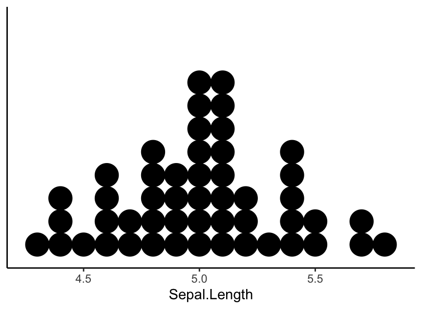

```r
setosa <- filter(iris, Species == "setosa")
ggplot(setosa, aes(x = Sepal.Length)) +
  geom_dotplot(binwidth = 0.1) +
  scale_y_continuous(NULL, breaks = NULL) + # <- remove the y-axis
  theme_classic()                           # <- remove the grid lines
```

## Boxplots

### Relationships between categorical and continuous data

## What are box and whiskers plots?

Box and whisker plots summarise the distributions of a variable at different levels of a categorical variable. Here is an example:

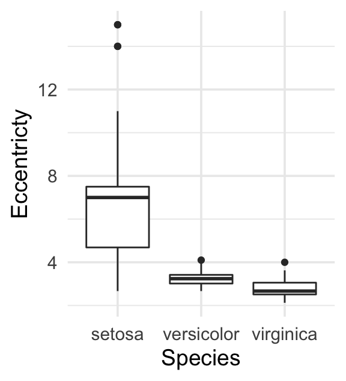

Each box-and-whisker shows the group median (line) and the interquartile range (“boxes”). The vertical lines (“whiskers”) highlight the range of the rest of the data in each group. Potential outliers are plotted individually.

## Making box and whiskers plots

You can guess which `geom_` function we use to make a boxplot…

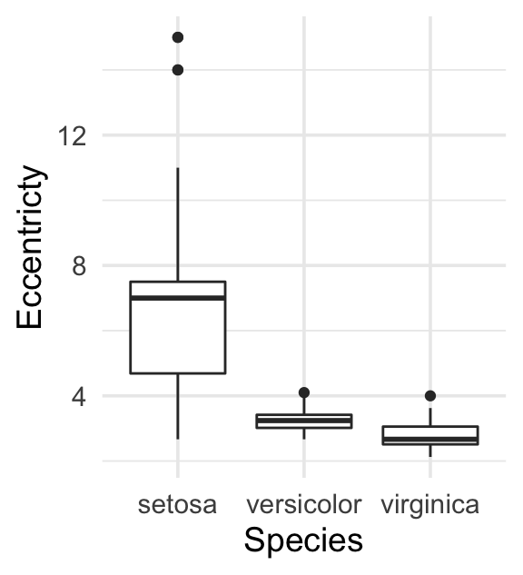

```r
ggplot(iris, aes(x = Species, y = Petal.Length/Petal.Width)) +
  geom_boxplot() +
  labs(x = "Species", y = "Eccentricty") +
  theme_minimal(base_size = 14)
```

## Exercise

**Box and whiskers plots**

Working with the `storms` dataset, construct a box and whiskers plot to summarise wind speed for each type of storm. Customise the fill colour of the boxes, get rid of the grey in the plot background, and increase the size of the text on the graph.

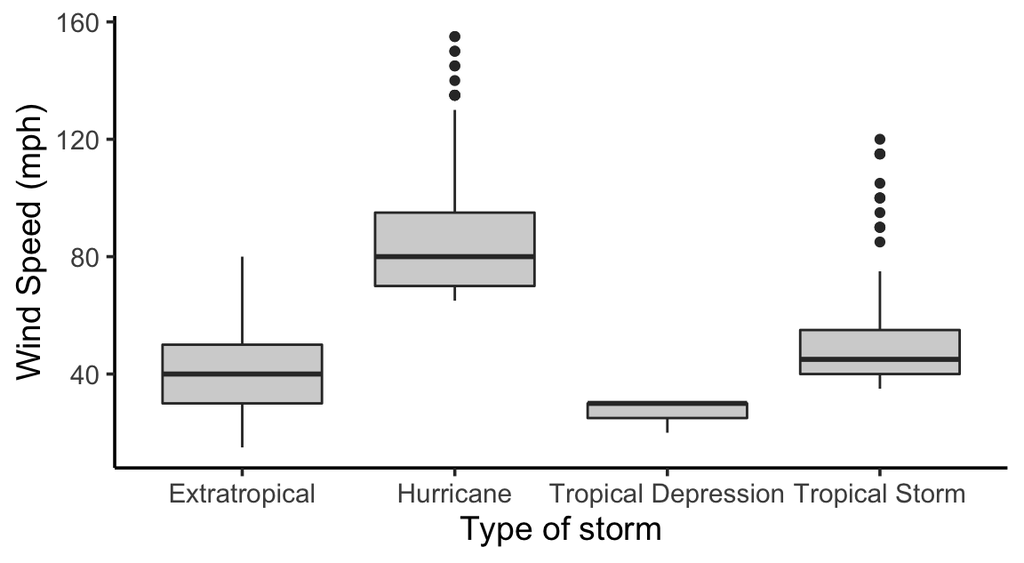

## Answer

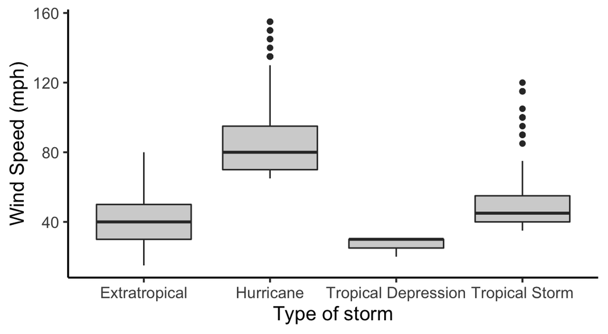

```r
ggplot(storms, aes(x = type, y = wind)) +
  geom_boxplot(fill= "lightgrey") +
  labs(x = "Type of storm", y = "Wind Speed (mph)") +
  theme_classic(base_size = 14)
```

## Saving plots (version 1)

We can save a plot using the `ggsave` function with `+` when we’re building our plot…

```r
# version 1.
ggplot(setosa, aes(x = Sepal.Length)) +
  geom_dotplot(binwidth = 0.1) +
  ggsave("Sepal_dotplot.pdf") # <- use ggsave as part of a ggplot construct
```

This saves the plot without displaying it in RStudio.

## Saving plots (version 2)

Or we can save a plot using the `ggsave` function on its own after we make the figure…

```r
# version 2.
ggplot(setosa, aes(x = Sepal.Length)) +
  geom_dotplot(binwidth = 0.1)
# use ggsave on its own *after* making the figure
ggsave("Sepal_dotplot.pdf")
```

This method is probably better as it displays the plot and then svaes it.

## Exercise

**Saving plots**

Use `ggsave` to save the box and whiskers plot that you just made. Look at the help file for `ggsave` and see if you can answer these two questions:

1. Can you work out where R has saved your plot to (i.e. which folder on your computer)?
2. Can you change the dimensions of the saved plot so that these are 4 inches x 4 inches?

## Answer

```r
# make the plot
ggplot(storms, aes(x = type, y = wind)) +
  geom_boxplot() +
  labs(x = "Type of storm", y = "Wind Speed")
# save it
ggsave("Windspeed_boxplot.pdf", height = 4, width = 4)
```

## Barplots

### Summary statistics for groups

## What are bar plots?

We typically use a barplot to summarise differences among groups. We can use `geom_bar` to make barplots but it will simply count the number of observations by default:

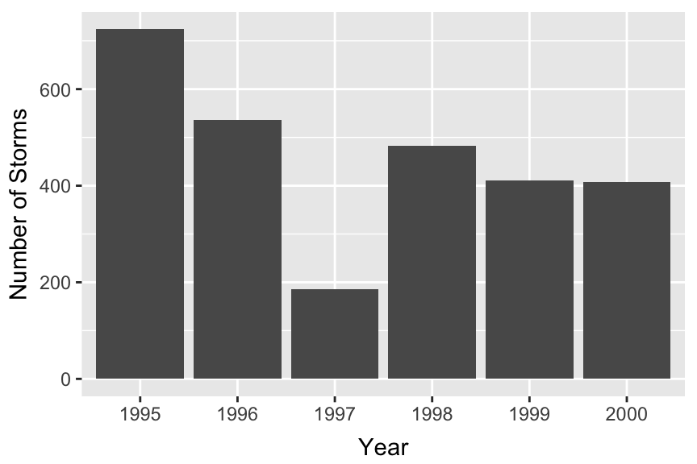

```r
ggplot(storms, aes(x = factor(year))) + # <- what is the 'factor' function doing?
  geom_bar() +
  labs(x = "Year", y = "Number of Storms")
```

This is not really very useful. Usually we use a bar plot to compare **summary statistics** (e.g. the mean).

## Using bar plots to compare means [step 1]

First we need to calculate the summary statistic. We can do this with the `group_by` and `summarise` function from the **dplyr** package. For example:

```r
# step 1
pl_stats <-
  iris %>%
  group_by(Species) %>%
  summarise(mean_pl = mean(Petal.Length))
```

## Using bar plots to compare means [step 2]

Second, make the plot. If we want to use a bar plot to compare a summary statistic (e.g. the mean) across groups we should use the `geom_col` function:

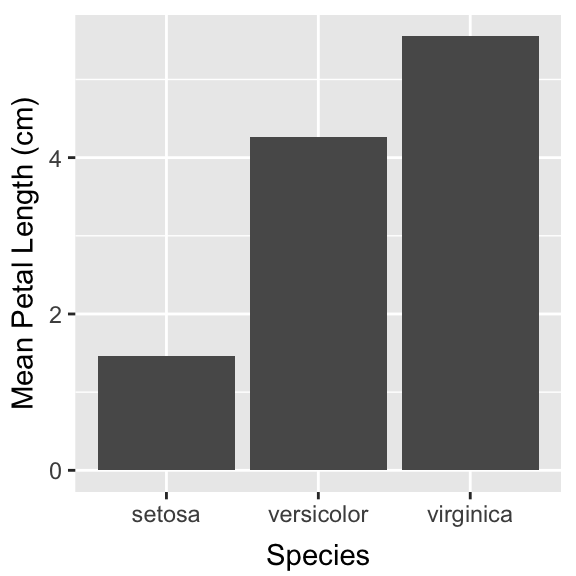

```r
# step 2
ggplot(pl_stats, aes(x = Species, y = mean_pl)) +
  geom_col() +
  labs(y = "Mean Petal Length (cm)")
```

## Exercise

**Making a barplot of means**

Working with the `storms` dataset, construct a bar plot to summarises the mean wind speed (`wind`) associated with storms in each year (`year`). Once you’ve made the plot see if you can change the colour of the bars to dark grey.

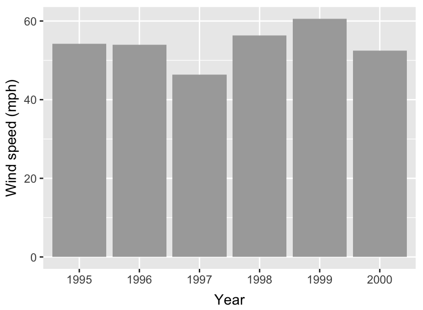

## Answer

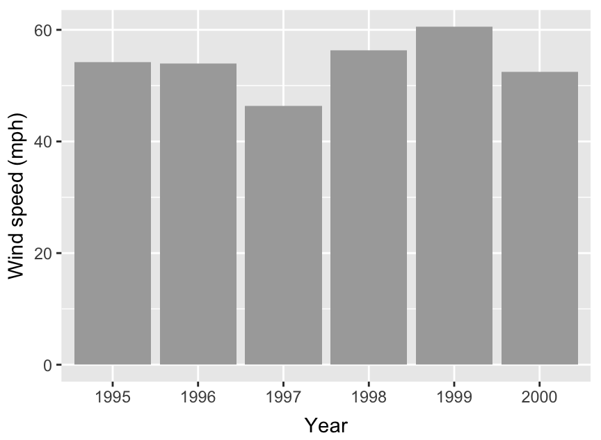

```r
# step 1 - use dplyr to calculate the means
wind.means <-
  storms %>% group_by(year) %>%
  summarise(mean= mean(wind))
# step 2 - make the plot
ggplot(wind.means, aes(x = factor(year), y = mean)) +
  geom_col(fill="darkgrey") +
  labs(x = "Year", y = "Wind speed (mph)")
```

## Adding multiple layers (1)

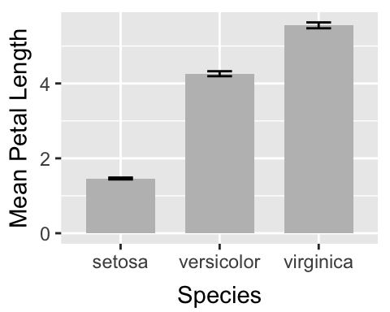

We can build more complex figures by adding more than one layer with the `geom_` functions. For example, we should usually try to include an error bar to numerical summaries (e.g. means).

The **standard error** is one option here:

\[ \text{Standard Error} = \frac{\text{Standard Deviation}}{\sqrt{\text{Sample Size}}} \]

## Adding multiple layers (1)

The **standard error** is one option here:

\[ \text{Standard Error} = \frac{\text{Standard Deviation}}{\sqrt{\text{Sample Size}}} \]

We need to repeat the **dplyr**, but now include a calculation of the standard errors along with the means:

```r
# step 1
pl_stats <-
  iris %>%
  group_by(Species) %>%
  summarise(mean_pl = mean(Petal.Length),
            se = sd(Petal.Length) / sqrt(n())) # <- New calculation
```

## Using multiple geoms (2)

Once we have the two bits of information, we include these by adding two layers via two different `geom_` functions: `geom_col` and `geom_errorbar`. We also need to define a couple of new aesthetics…

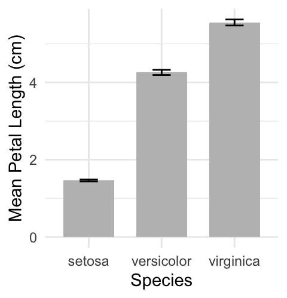

```r
# step 2
ggplot(pl_stats,
       aes(x = Species, y = mean_pl,
           ymin = mean_pl - se, ymax = mean_pl + se)) +
  geom_col(fill = "grey", width = 0.7) +
  geom_errorbar(width = 0.25) +
  labs(y = "Mean Petal Length (cm)") + theme_minimal()
```

## Exercise

**Adding error bars to your plot**

Go back to the bar plot you just made using the `storms` data set and add error bars showing the standard errors of wind speed.

## Answer

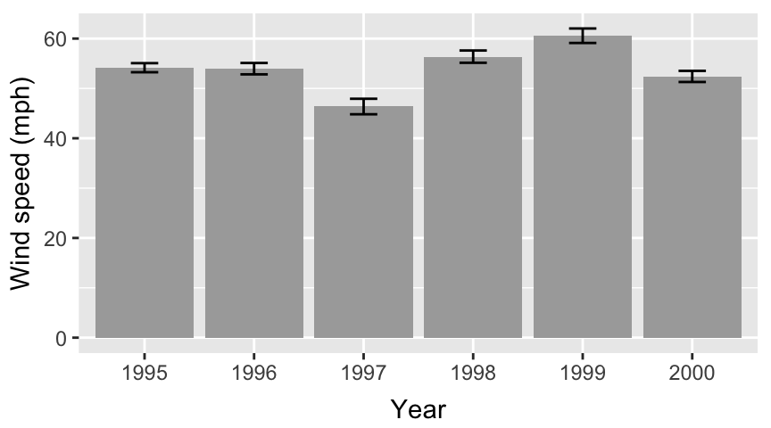

```r
# step 1 - use dplyr to calculate the means
wind.means <-
  storms %>% group_by(year) %>%
  summarise(mean = mean(wind),
            se = sd(wind)/sqrt(n()))

# step 2 - make the plot
ggplot(wind.means, aes(x = factor(year), y = mean,
                       ymin = mean - se, ymax = mean + se)) +
  geom_col(fill="darkgrey") +
  geom_errorbar(width = 0.25) +
  labs(x = "Year", y = "Wind speed (mph)")
```

## Exercise

**Putting it all together**

Have a look at the built in data set in R called `ChickWeight`. Make sure you understand what variables it contains, then try to make two plots below. Think about a) what these two graphs tell you about the effectiveness of the four diets and b) what other information it might be useful to include.

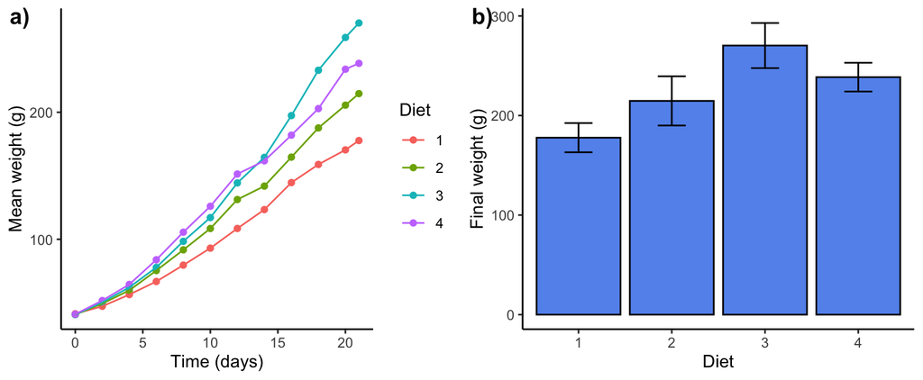

## Answer

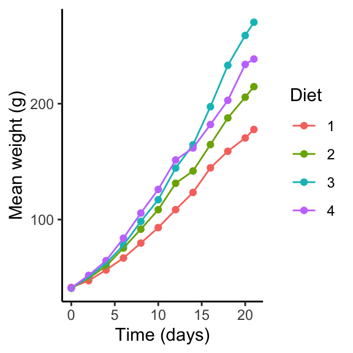

```r
## Calculate the mean and standard errors for each diet at each time point
pltdata<- group_by(ChickWeight, Time, Diet) %>%
  summarise(mn = mean(weight), se = sd(weight)/sqrt(n()))
## Plot the means over time - remembering to colour by the diet
plta <- ggplot(pltdata, aes(x=Time, y = mn, colour = Diet)) +
  geom_point() +
  geom_line() + ## Unsurprisingly the function for adding lines to our plot is geom_line
  theme_classic() +
  labs(y = "Mean weight (g)", x = "Time (days)")
plta
```

## Answer

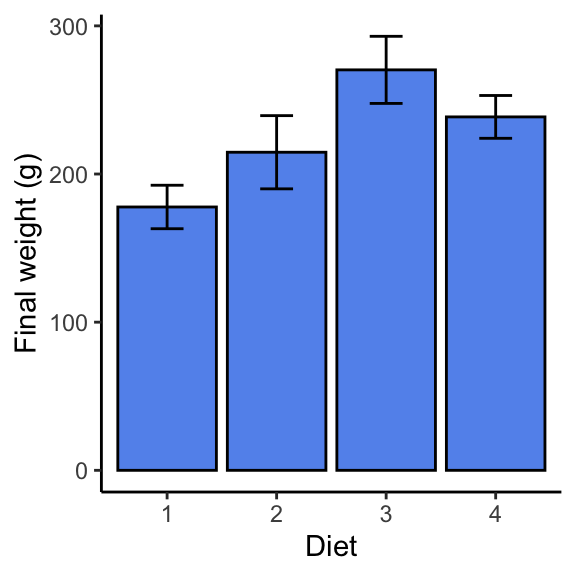

```r
## Filter the summary data to only include the final weights
pltdata2 <- ungroup(pltdata) %>%
  filter(Time==max(Time))
## Make a bar plot of the means and standard errors
pltb <- ggplot(pltdata2, aes(x=Diet, y = mn, ymin = mn-se, ymax = mn+se)) +
  geom_col(fill = 'cornflowerblue', colour = "black") +
  geom_errorbar(width = 0.3) +
  labs(y = "Final weight (g)") +
  theme_classic()
pltb
```

## A final trick…

We can then use the `plot_grid` function to make a panel plot containing both graphs. This function is from the `cowplot` package so you’ll need to have that loaded (remember if you haven’t used it before then you’ll need to install it first using install.packages).

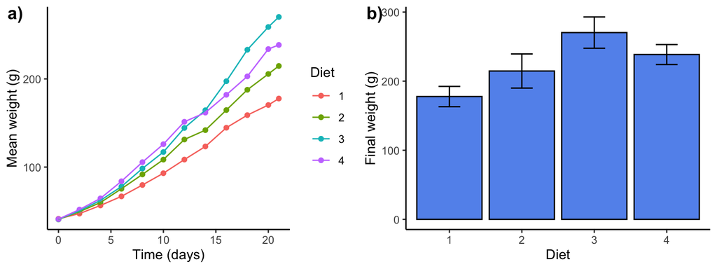

```r
library(cowplot)
plot_grid(plta, pltb, labels = c("a)", "b)"))
```

## Answer

Useful additional information could include:

1. Sample sizes
2. Results of a statistical test
3. What are the different diets?

## Congratulations! We’re done!